# Linguistic Data: Quantitative Analysis and Visualisation

Lab on a Student’s t-test

### Aspiration and vowel duration in Icelandic

This set is based on (Coretta 2017, https://goo.gl/NrfgJm). This dissertation dealt with the relation between vowel duration and aspiration in consonants. Author carried out a data collection with 5 natives speakers of Icelandic. Then he extracted the duration of vowels followed by aspirated versus non-aspirated consonants. Check out whether vowels before aspirated consonants (like in Icelandic takka ‘key’ [tʰaʰka]) are signiﬁcantly shorter than vowels followed by non-aspirated consonants (like in kagga ‘barrel’ [kʰakka]). Link to the dataset: http://math-info.hse.ru/f/2018-19/ling-data/icelandic.csv.

```r
df <- read.csv("http://math-info.hse.ru/f/2018-19/ling-data/icelandic.csv")
```

### Descriptive statistics

General boxplot:

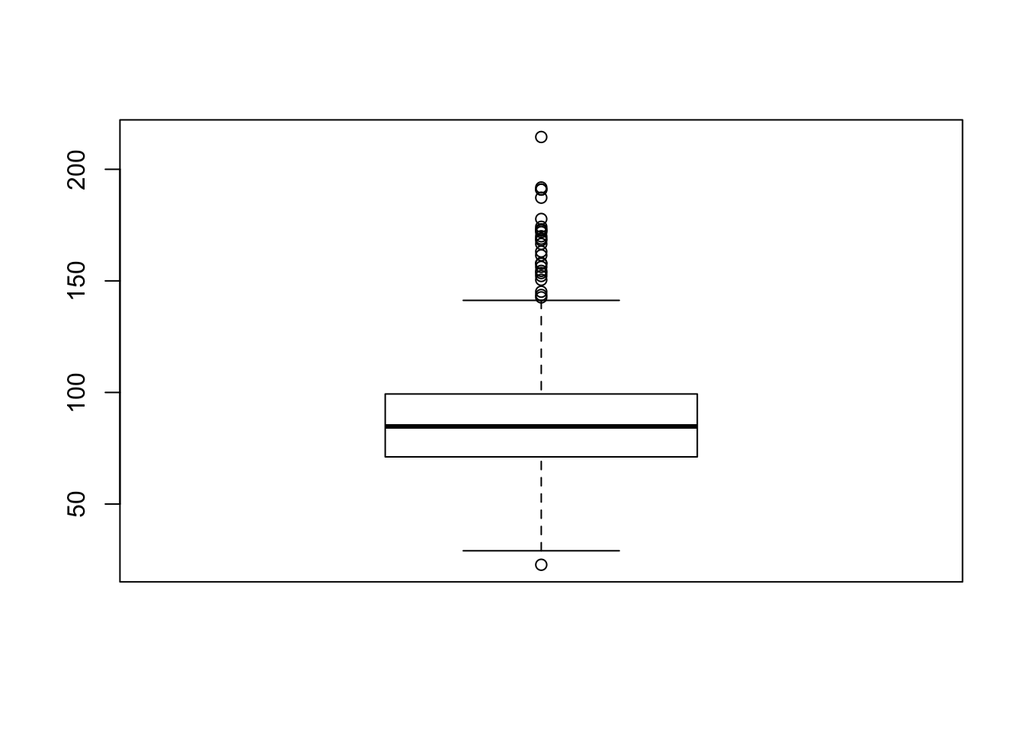

```r
boxplot(df$vowel.dur)
```

The number of outliers:

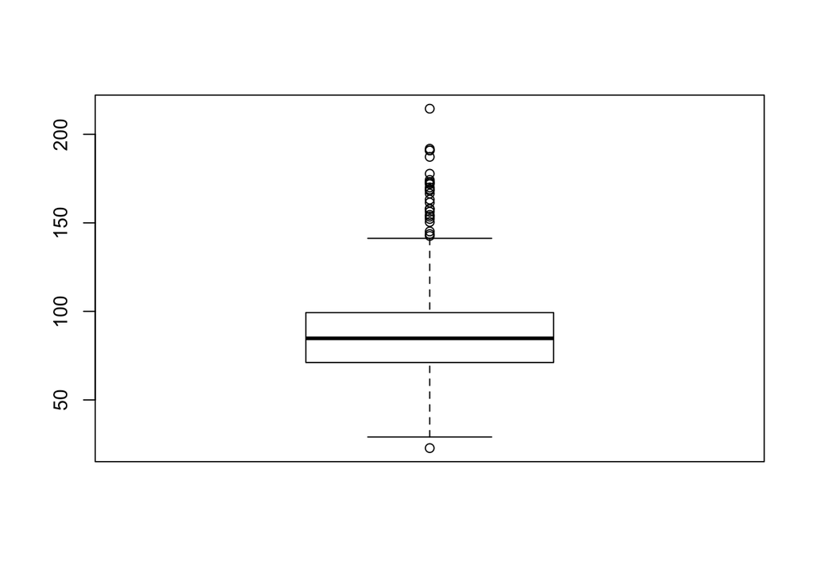

```
## [1] 27
```

```r
length(boxplot(df$vowel.dur)$out)
```

```r
table(df$aspriration)
```

```
## < table of extent 0 >
```

Choose two subsamples, aspirated and non-aspirated.

```r
asp <- df[df$aspiration == 'yes',]
nasp <- df[df$aspiration == 'no',]
```

Summary for aspirated and non-aspirated cases:

```r
summary(asp$vowel.dur)
```

```
##    Min. 1st Qu.  Median    Mean 3rd Qu.    Max.
##   22.78   64.96   77.60   78.76   91.46  166.56
```

```r
summary(nasp$vowel.dur)
```

```
##    Min. 1st Qu.  Median    Mean 3rd Qu.    Max.
##   37.98   77.56   91.91   94.69  103.88  214.48
```

Boxplot for groups:

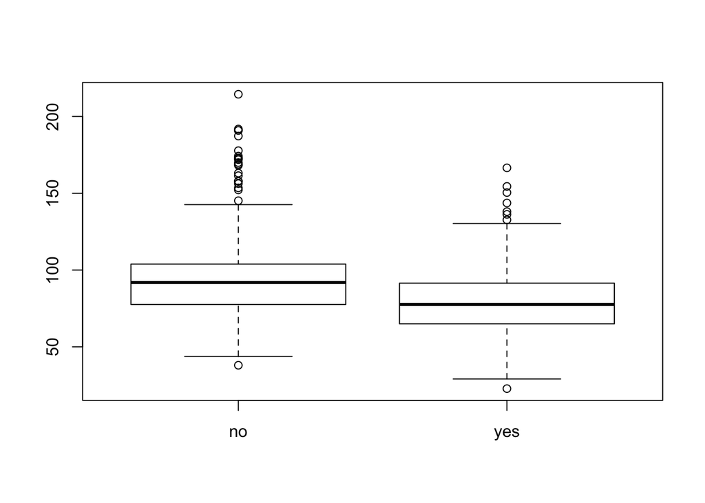

```r
boxplot(df$vowel.dur ~ df$aspiration)
```

More interesting - let us create boxplot by all groups, see the field `cons1`.

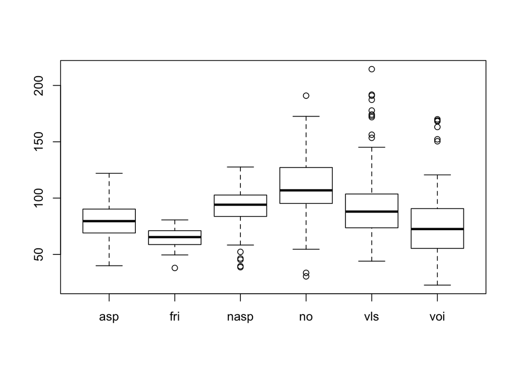

```r
boxplot(df$vowel.dur ~ df$cons1)
```

You can compare distribution of `vowel.dur` in asp(irated), fri(cative), nasp(non-aspirated), voi(ced), etc.

We can limit our data to just one type of vowels, say, middle vowels. Therefore, we will work with the same type of a consonant:

```r
asp <- df[df$aspiration == 'yes' & df$height == 'mid', ]
nasp <- df[df$aspiration == 'no' & df$height == 'mid', ]
```

Again, here is a summary for a corrected case:

```r
summary(asp$vowel.dur)
```

```
##    Min. 1st Qu.  Median    Mean 3rd Qu.    Max.
##   38.67   71.41   81.92   82.65   95.19  150.46
```

```r
summary(nasp$vowel.dur)
```

```
##    Min. 1st Qu.  Median    Mean 3rd Qu.    Max.
##   37.98   80.90   97.97   98.73  110.51  190.93
```

```r
nrow(asp)
```

```
## [1] 156
```

```r
nrow(nasp)
```

```
## [1] 174
```

### T-test

Let us formulate the null hypothesis, the alternative hypotesis, and apply t-test to our dataset.

```r
t.test(asp$vowel.dur, nasp$vowel.dur)
```

```
##
##  Welch Two Sample t-test
##
## data:  asp$vowel.dur and nasp$vowel.dur
## t = -6.4869, df = 317.72, p-value = 3.356e-10
## alternative hypothesis: true difference in means is not equal to 0
## 95 percent confidence interval:
##  -20.94772 -11.19801
## sample estimates:
## mean of x mean of y
##  82.65371  98.72657
```

By default, R calculates t.test with regard to the bi-directional alternative hypothesis, such as $\mu_1 \neq \mu_2$.

### Unidirectional t-test

H1: $\mu_{asp} \lt \mu_{nasp}$

```r
t.test(asp$vowel.dur, nasp$vowel.dur, alternative = "less")
```

```
##
##  Welch Two Sample t-test
##
## data:  asp$vowel.dur and nasp$vowel.dur
## t = -6.4869, df = 317.72, p-value = 1.678e-10
## alternative hypothesis: true difference in means is less than 0
## 95 percent confidence interval:
##       -Inf -11.98542
## sample estimates:
## mean of x mean of y
##  82.65371  98.72657
```

### Density plots

```r
require(tidyverse)
require(dplyr)
```

Let’s get a descriptive summary of our data in a dplyr style.

```r
df %>%
  group_by(aspiration) %>%
  summarise(mean = mean(vowel.dur),
            st.dev = sd(vowel.dur))
```

```
## # A tibble: 2 x 3
##   aspiration  mean st.dev
##   <fct>      <dbl>  <dbl>
## 1 no          94.7   25.9
## 2 yes         78.8   21.2
```

Density plots can be thought of as plots of smoothed histograms.

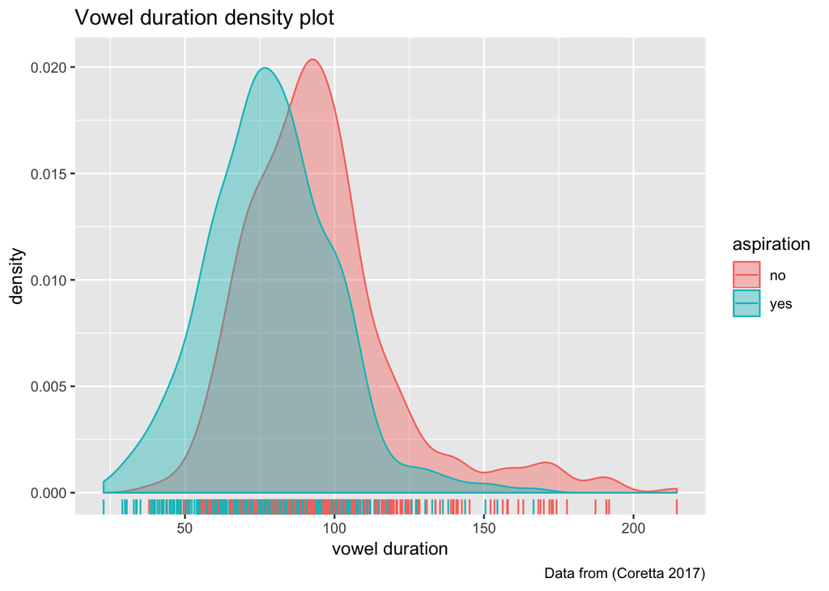

```r
library(ggplot2)
df %>%
  ggplot(aes(vowel.dur, fill = aspiration, color = aspiration))+
  geom_density(alpha = 0.4)+
  geom_rug()+
  labs(title = "Vowel duration density plot",
       caption = "Data from (Coretta 2017)",
       x = "vowel duration")
```

Density plot by speaker:

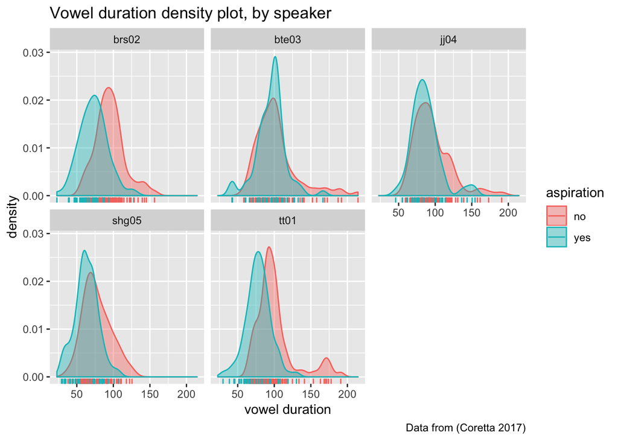

```r
df %>%
  ggplot(aes(vowel.dur, fill = aspiration, color = aspiration))+
  geom_density(alpha = 0.4)+
  geom_rug()+
  facet_wrap(~speaker)+
  labs(title = "Vowel duration density plot, by speaker",
       caption = "Data from (Coretta 2017)",
       x = "vowel duration")
```

and descriptive statistics:

```r
df %>%
  group_by(aspiration, speaker) %>%
  summarise(mean = mean(vowel.dur),
            st.dev = sd(vowel.dur))
```

```
## # A tibble: 10 x 4
## # Groups:   aspiration [?]
##    aspiration speaker  mean st.dev
##    <fct>      <fct>   <dbl>  <dbl>
##  1 no         brs02    95.3   19.8
##  2 no         bte03   103.    29.4
##  3 no         jj04     95.7   25.1
##  4 no         shg05    77.7   18.9
##  5 no         tt01    101.    26.8
##  6 yes        brs02    72.9   18.9
##  7 yes        bte03    95.4   20.0
##  8 yes        jj04     86.8   20.1
##  9 yes        shg05    63.3   15.7
## 10 yes        tt01     78.3   16.7
```